# NMSU Employee Insights

The graphs created below will uncover information about the positions held and the salaries earned by NMSU employees in various demographic groups (2010). Data was downloaded from DataUSA.

```python
import pandas as pd
import matplotlib.pyplot as plt

salary_df = pd.read_pickle('nmsu_salaries_cleaned.pkl')

# Sort data by increasing salary
salary_df = salary_df.sort_values('Salary')
salary_df = salary_df.reset_index()
salary_df.head()
```

|  | index | Salary | Department | Title | EstimatedRace | RMP_overall_rating | RMP_num_ratings | EstimatedGender |
| --- | --- | --- | --- | --- | --- | --- | --- | --- |
| 0 | 2285 | 100000 | Athletics | Deputy Dir,Athletics | nh_white | NaN | NaN | male |
| 1 | 463 | 100000 | SW Technology Development Institute | SWTDI Director | nh_white | NaN | NaN | male |
| 2 | 2919 | 100353.02 | NMDA Veterinary Diagnostic Svc | Vet Pathologist | nh_white | NaN | NaN | male |
| 3 | 235 | 100565.11 | Art | Acad Dept Head | nh_white | 3.7 | 3.0 | female |
| 4 | 3349 | 100632.97 | Entomology Plant Path and Weed Sci | Acad Dept Head | nh_white | NaN | NaN | male |

```python
# Change data type from object to float, and then to integer
salary_df['Salary'] = salary_df['Salary'].astype(float)
salary_df['Salary'] = salary_df['Salary'].astype(int)

# Drop columns im not interested in
salary_df = salary_df.drop(columns=['RMP_overall_rating','RMP_num_ratings'],axis=1)

# Change categorical values for simplicity
salary_df['EstimatedRace'] = salary_df['EstimatedRace'].str.replace('nh_white','white')
salary_df['EstimatedRace'] = salary_df['EstimatedRace'].str.replace('nh_black','black')
```

**Identify the percentage of all positions held by various demographic groups**

```python
# Fx to find the percent of positions held by a given demographic
def percent_of_positions(df, column_name, value):
    data_subset = df[df[column_name]==(value)]
    percent = len(data_subset)/len(df) * 100
    result = round(percent,2)
    return result

# Fx to create percent data dictionaries
def create_data(df, column_name):
    if column_name == 'EstimatedGender':
        data = {'female':0, 'male':0}
        for value in data:
            data[value] = percent_of_positions(df, column_name, value)
        data['unknown'] = round(100 - (data['female'] + data['male']), 2)
        return data
    elif column_name == 'EstimatedRace':
        data = {'white':0, 'hispanic':0, 'asian':0, 'black':0}
        for value in data:
            data[value] = percent_of_positions(df, column_name, value)
        data['nonwhite'] = round(data['hispanic'] + data['asian'] + data['black'], 2)
        return data

perc_gender = create_data(salary_df, 'EstimatedGender')
perc_race = create_data(salary_df, 'EstimatedRace')

print('Gender percentages: ', perc_gender)
print('Race percentages: ', perc_race)
```

```
Gender percentages:  {'female': 49.54, 'male': 42.49, 'unknown': 7.97}
Race percentages:  {'white': 64.24, 'hispanic': 29.97, 'asian': 3.25, 'black': 2.54, 'nonwhite': 35.76}
```

**Identify the percentage of Professor positions held by various demographic groups**

```python
# Isolate professor data
titles = ['Asst Prof', 'Assc Prof', 'Professor', 'Professor, Distinguished']
prof_df = salary_df[salary_df['Title'].isin(titles)]

prof_perc_gender = create_data(prof_df, 'EstimatedGender')
prof_perc_race = create_data(prof_df, 'EstimatedRace')

print('Gender percentages: ', prof_perc_gender)
print('Race percentages: ', prof_perc_race)
```

```
Gender percentages:  {'female': 36.76, 'male': 49.02, 'unknown': 14.22}
Race percentages:  {'white': 72.16, 'hispanic': 14.83, 'asian': 10.44, 'black': 2.57, 'nonwhite': 27.84}
```

**Identify the percentage of Department Head positions held by various demographic groups**

```python
# Isolate department head data
dh_df = salary_df[salary_df['Title']==("Acad Dept Head")]

dh_perc_gender = create_data(dh_df, 'EstimatedGender')
dh_perc_race = create_data(dh_df, 'EstimatedRace')

print('Gender percentages: ', dh_perc_gender)
print('Race percentages: ', dh_perc_race)
```

```
Gender percentages:  {'female': 21.43, 'male': 76.19, 'unknown': 2.38}
Race percentages:  {'white': 88.1, 'hispanic': 7.14, 'asian': 4.76, 'black': 0.0, 'nonwhite': 11.9}
```

**Identify percentage of Dean positions held by various demographic groups**

```python
# Isolate dean data
dean_df = salary_df[salary_df['Title'].str.contains('Dean')]

dean_perc_gender = create_data(dean_df, 'EstimatedGender')
dean_perc_race = create_data(dean_df, 'EstimatedRace')

print('Gender percentages: ', dean_perc_gender)
print('Race percentages: ', dean_perc_race)
```

```
Gender percentages:  {'female': 40.62, 'male': 53.12, 'unknown': 6.26}
Race percentages:  {'white': 84.38, 'hispanic': 12.5, 'asian': 0.0, 'black': 3.12, 'nonwhite': 15.62}
```

**Figure 1 describes the percentage of positions held by male versus female and whites versus nonwhites (estimated).**

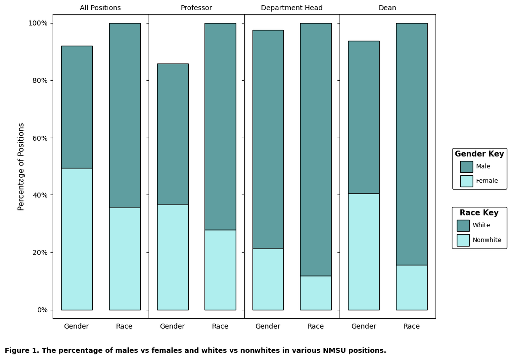

```python
fig,ax = plt.subplots(1,4,figsize=(10,8))
plt.subplots_adjust(wspace=0, hspace=0.13)
width = 1.3
x = [2,4]

# List of above percentages to use for the subplots.
mino = [[perc_gender['female'], perc_race['nonwhite']],[prof_perc_gender['female'], prof_perc_race['nonwhite']],[dh_perc_gender['female'], dh_perc_race['nonwhite']],
        [dean_perc_gender['female'],dean_perc_race['nonwhite']]]
maj = [[perc_gender['male'],perc_race['white']],[prof_perc_gender['male'],prof_perc_race['white']],[dh_perc_gender['male'],dh_perc_race['white']],
       [dean_perc_gender['male'],dean_perc_race['white']]]

titles = ['All Positions', 'Professor', 'Department Head', 'Dean']

# axes parameters
for i in range(4):
    ax1 = ax[i].bar(x, mino[i],width=1.3,edgecolor='black',color='paleturquoise')
    ax2 = ax[i].bar(x, maj[i], width, bottom=mino[i], edgecolor='black',color='cadetblue')
    ax[i].tick_params(bottom=False)
    ax[i].set_xticks([1, 2, 4, 5])
    ax[i].set_xticklabels(['','Gender','Race', ''])
    ax[i].set_xlim(1,5)
    ax[i].set_ylim(-3,103)
    ax[i].set_title(titles[i],size=10)
    if i == 0:
        ax[i].set_yticks([0, 20, 40, 60, 80, 100])
        ax[i].set_yticklabels(['0%','20%','40%','60%','80%','100%'])
        ax[i].set_ylabel('Percentage of Positions', size=11)
    else:
        ax[i].set_yticks([0, 20, 40, 60, 80, 100])
        ax[i].set_yticklabels([])

#Make the figure legends
key = {'labels':[['Male','Female'], ['White','Nonwhite']], 'bbox':[(1.05, 0.55),(1.05, 0.4)], 'title':['Gender Key', '  Race Key  ']}
for i in range(2):
    fig.legend([ax2,ax1], key['labels'][i],loc='upper right', bbox_to_anchor=key['bbox'][i],
            edgecolor='black', title=key['title'][i], title_fontproperties=dict(weight='semibold', size=11),
            handlelength=2,handleheight=2.5,handletextpad=.5,fontsize=9)

#The subtitle for the figure
plt.text(-13,-15, 'Figure 1. The percentage of males vs females and whites vs nonwhites in various NMSU positions.',
         weight='bold')

plt.show()
```

As shown above, there is a somewhat even split of men and women for all positions (the absence of some percentage points is due to missing data) except for Department Heads, where 76% are male. However, over 50% of all positions are held by those who are estimated to be white (non-hispanic). This is interesting considering that the population of Dona Ana county is estimated to be only 27% non-hispanic white (according to https://datausa.io/). For professors, less than 30% are estimated to be non-white. The majority of department head positions are held by white men, with only approximately 20% women and 10% non-white. Less than 20% of deans are estimated to be non-white.

**Identify the percentage of demographic groups holding positions in each salary group**: less than $50k, $50-100k, $100-200k, $200k and above

```python
low_df = salary_df[salary_df['Salary']<50000]
midlow_df = salary_df[(salary_df['Salary']>=50000) & (salary_df['Salary']<100000)]
midhigh_df = salary_df[(salary_df['Salary']>=100000) & (salary_df['Salary']<200000)]
high_df = salary_df[salary_df['Salary']>=200000]

perc_gender_high = create_data(high_df, 'EstimatedGender')
perc_race_high = create_data(high_df, 'EstimatedRace')
print('Gender percentages, >=200k: ', perc_gender_high)
print('Race percentages, >=200k: ', perc_race_high)
```

```
Gender percentages, >=200k:  {'female': 16.67, 'male': 66.67, 'unknown': 16.66}
Race percentages, >=200k:  {'white': 91.67, 'hispanic': 0.0, 'asian': 8.33, 'black': 0.0, 'nonwhite': 8.33}
```

```python
perc_gender_midhigh = create_data(midhigh_df, 'EstimatedGender')
perc_race_midhigh = create_data(midhigh_df, 'EstimatedRace')
print('Gender percentages, 100-200k: ', perc_gender_midhigh)
print('Race percentages, 100-200k: ', perc_race_midhigh)
```

```
Gender percentages, 100-200k:  {'female': 31.54, 'male': 59.62, 'unknown': 8.84}
Race percentages, 100-200k:  {'white': 80.0, 'hispanic': 11.15, 'asian': 6.92, 'black': 1.92, 'nonwhite': 19.99}
```

```python
perc_gender_midlow = create_data(midlow_df, 'EstimatedGender')
perc_race_midlow = create_data(midlow_df, 'EstimatedRace')
print('Gender percentages, 50-100k: ', perc_gender_midlow)
print('Race percentages, 50-100k: ', perc_race_midlow)
```

```
Gender percentages, 50-100k:  {'female': 42.02, 'male': 48.29, 'unknown': 9.69}
Race percentages, 50-100k:  {'white': 74.29, 'hispanic': 17.49, 'asian': 5.57, 'black': 2.65, 'nonwhite': 25.71}
```

```python
perc_gender_low = create_data(low_df, 'EstimatedGender')
perc_race_low = create_data(low_df, 'EstimatedRace')
print('Gender percentages, <50k: ', perc_gender_low)
print('Race percentages, <50k: ', perc_race_low)
```

```
Gender percentages, <50k:  {'female': 56.65, 'male': 36.63, 'unknown': 6.72}
Race percentages, <50k:  {'white': 55.8, 'hispanic': 40.35, 'asian': 1.3, 'black': 2.55, 'nonwhite': 44.2}
```

**Figure 2 describes the percentage of males and females in each salary tier**

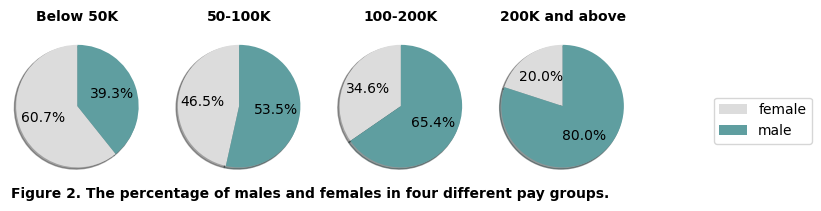

```python
# Sizes each piece of the pie will be (4 pies total)
sizes = [[perc_gender_low['female'], perc_gender_low['male']],
         [perc_gender_midlow['female'], perc_gender_midlow['male']],
         [perc_gender_midhigh['female'], perc_gender_midhigh['male']],
         [perc_gender_high['female'], perc_gender_high['male']]]

titles = ['Below 50K', '50-100K', '100-200K', '200K and above']

fig,ax = plt.subplots(1,4, figsize=(8,2))

for i in range(4):
    ax[i].pie(sizes[i],autopct='%1.1f%%',shadow=True, startangle=90, colors=['gainsboro','cadetblue'])
    ax[i].axis('equal')
    ax[i].set_title(titles[i], size=10, weight='bold')
    if i == 0:
        ax[0].legend(labels = ['female','male'], bbox_to_anchor=(6, 0.6))

plt.text(-9,-1.5, 'Figure 2. The percentage of males and females in four different pay groups.', weight='bold')

plt.show()
```

The above figure uncovers the increase in male (and decrease in female) representation as salary increases.

**Figure 3 describes the percentage of each race group in each salary tier**

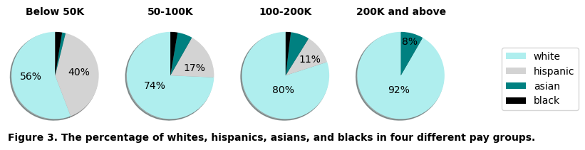

```python
label = ['white','hispanic', 'asian', 'black']
dicts = [perc_race_low, perc_race_midlow, perc_race_midhigh, perc_race_high]
# Sizes of each piece of the pie
sizes = []
for dict in dicts:
    sizes.append([dict['white'], dict['hispanic'], dict['asian'], dict['black']])

titles = ['Below 50K', '50-100K', '100-200K', '200K and above']

fig,ax = plt.subplots(1,4, figsize=(8,2))

for i in range(4):
    ax[i].pie(sizes[i],shadow=True, startangle=90, colors=['paleturquoise','lightgray', 'teal','black'],)
    ax[i].axis('equal')
    ax[i].set_title(titles[i], size=10, weight='bold')

ax[0].legend(labels = label, bbox_to_anchor=(6, 0.8))

# Percent text annotations
locs = [[[-0.8,-0.1], [0.3,0]], [[-0.6,-0.3], [0.3,0.1]], [[-0.3,-0.4], [0.3,0.3]], [[-0.3,-0.4], [0.03,0.7]]]
percents = [['56%', '40%'], ['74%', '17%'], ['80%', '11%'], ['92%', '8%']]
for i in range(4):
    ax[i].text(locs[i][0][0], locs[i][0][1], percents[i][0])
    ax[i].text(locs[i][1][0], locs[i][1][1], percents[i][1])

plt.text(-9,-1.5, 'Figure 3. The percentage of whites, hispanics, asians, and blacks in four different pay groups.', weight='bold')

plt.show()
```

Figure 3 exposes the increase in white people holding positions at NMSU as the salary for those positions increase. Subsequently, there is a dramatic decrease of representation of hispanic people as salary increases.

### Conclusion

These data visualizations have exposed the liklihood of underrepresentation of minority groups at NMSU, specifically for higher paid positions. It's important to keep in mind that the data was created by algorithmically *estimating* the gender and race of the individuals in the data set. The data used was from DataUSA collected in 2010. It would be of interest to acquire updated data to compare to this dataset to determine if any progress has been made in the representation of minority groups at NMSU.